# Menopause plots

Glen Oct 2025 For making plots

current plots it makes:

```r
gRootName = "yoglen"
outputDir = "/home/glen/yoglen"

source(sprintf("%s/menopause_script.R",outputDir),verbose=0)
library(ggplot2)
library(gridExtra) #needed for several plots
library(ggrepel) #needed for labels in one plot
```

```r
keep_list = read.csv(sprintf("%s/data/variable_keep_list.csv",outputDir),row.names=1)
keepList = keep_list

systemCodex = read.csv(sprintf("%s/data/system_codex.csv",outputDir),row.names=1)
rownames(systemCodex)=systemCodex[,"variable"]


codex = read.csv(sprintf("%s/data/nhanes_preproc_codex.csv",outputDir),row.names=1)
rownames(codex)=codex[,"name"]
```

menopause median and IQR:

```r
save=F
load=T
file   = sprintf("%s/results/nhanes_menopause_menopause_quantiles.csv",outputDir)
if(file.exists(file) & load)
{
  #print("file found")
  r = read.csv(file,row.names=1)
} else
{

    dataFile = sprintf("%s/data/nhanes_data.csv",outputDir)
  useSim=F
  if(file.exists(dataFile)) #real data
  {
    print("real data found")
    Xf = read.csv(dataFile,row.names=1) #real data
    Xmi = readRDS(sprintf("%s/data/nhanes_data_mi.rds",outputDir)) #real data
  } else #sim data
  {
    print("real data not found, using simulated...")
    useSim =  T
    Xf = read.csv(sprintf("%s/data/yoglen_simulated_nhanes_data_with_outcomes.csv",outputDir),row.names=1)
    Xmi = readRDS(sprintf("%s/data/yoglen_simulated_nhanes_data_with_outcomes_mi.rds",outputDir))

    Xf[,"RIDAGEYR"] = Xf[,"age"] #I named it differently in the simulated data
    Xf[,"depression_score"] = Xf[,"depression_score_num"]
    for (k in 1:length(Xmi))
    {
      Xmi[[k]][,"RIDAGEYR"] = Xmi[[k]][,"age"]
      Xmi[[k]][,"depression_score"] = Xmi[[k]][,"depression_score_num"]
    }

  }

  l = list()
  for (i in 1:length(Xmi))
  {
    l[[i]] = matrix(quantile(Xmi[[i]][,"age_menopause"],probs=c(.25,.5,.75),na.rm=T),nrow=1,ncol=3)
    colnames(l[[i]])=sprintf("Q%.0f",c(25,50,75))
  }
  r = RubinMat(l)
  r = rbind(r[[1]],r[[2]])
  colnames(r)[colnames(r)=="Q50"] = "median"
  rownames(r) = c("estimate","standard error")
  if(save) write.csv(r,file,row.names=T)
}
print(r)
```

|  | Q25 | median | Q75 |
| --- | --- | --- | --- |
| estimate | 44 | 49 | 53 |
| standard error | 0 | 0 | 0 |

```r
opts =  "stats_ac"

tcuts   = seq(-25.5,25,by=1)
vars    = subset(keep_list,group!="none")[,"variable"]
vars = c(vars,"depression_score_num")



filef   = sprintf("%s/results/nhanes_menopause_female_mean_%s.csv",outputDir,opts)
filefsd = sprintf("%s/results/nhanes_menopause_female_sd_%s.csv",outputDir,opts)
filem   = sprintf("%s/results/nhanes_menopause_male_mean_%s.csv",outputDir,opts)
filemsd = sprintf("%s/results/nhanes_menopause_male_sd_%s.csv",outputDir,opts)

if(file.exists(filef))
{
  aggf = read.csv(filef)
  aggfsd = read.csv(filefsd)
  aggm   = read.csv(filem)
  aggmsd = read.csv(filemsd)
} else
{
  stop("data not found, you must download from zenodo repository (I might put it up on github too but I'm mercurial about it)")

}

aggf[,"sex"] = "female"
aggm[,"sex"] = "male"
agg = rbind(aggf,aggm)
agg0=agg
```

load cross-validated models

```r
file=sprintf("%s/results/nhanes_menopause_model_selection_%s.rds",outputDir,"ac") #available case
#file=sprintf("%s/results/nhanes_menopause_model_selection_%s.rds",outputDir,"mi")  #imputed
filem=sprintf("%s/results/nhanes_menopause_model_selection_males_%s.rds",outputDir,"ac") #available case

models = list(splineJump = GAMSplineJump,spline = GAMSpline,pwGAULSS=GAMSplineQuasiPWGAULSS, GAULSS=GAMSplineGAULSS)
if(file.exists(file))
{
  ms=readRDS(file)
} else
{
  print(file)
  stop("download from zenodo")
}


if(file.exists(filem))
{
  msm=readRDS(filem)
} else
{
  print(filem)
  stop("download from zenodo")
}
```

#Figure 1 c and d

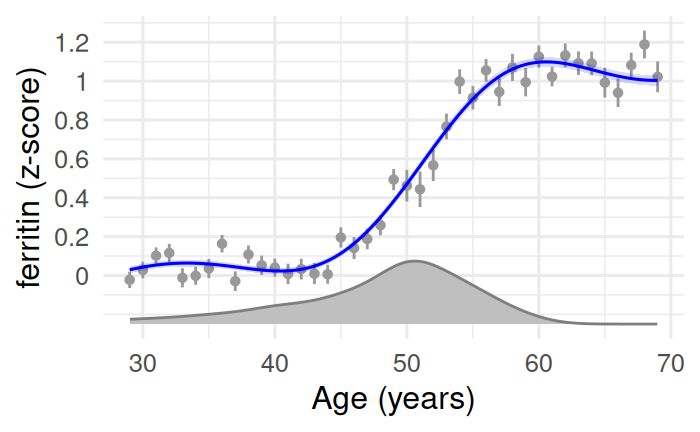

```r
var = "ferritin"
names(var)="ferritin"
ylab=sprintf("%s (z-score)",names(var))

useImputed=FALSE
medAge=49 #have to manually change gam below
tcuts =seq(-21,20,by=1)+.5+medAge
xlim=c(tcuts[1]+.5,tcuts[length(tcuts)]-.5)
ttest = seq(xlim[1],xlim[2],length=256)
perimenoLim=c(-8,-0.1)+medAge
earlyPostLim=c(0.1,4.9)+medAge
latePostLim=c(5.1,10)+medAge
yshift = .25 #moves plot up

load=T
save=T
opts = "stats"
if(!useImputed) opts = sprintf("%s_ac",opts)
file   = sprintf("%s/results/nhanes_menopause_female_mean_by_age_%s.csv",outputDir,opts)
filesm   = sprintf("%s/results/nhanes_menopause_female_smooth_spline_by_age_%s.csv",outputDir,opts)

if(file.exists(file) & load)
{
  agga  = read.csv(file)
  aggsm = read.csv(filesm)
} else
{
  dataFile = sprintf("%s/data/nhanes_data.csv",outputDir)
  useSim=F
  if(file.exists(dataFile)) #real data
  {
    print("real data found")
    Xf = read.csv(dataFile,row.names=1) #real data
    Xmi = readRDS(sprintf("%s/data/nhanes_data_mi.rds",outputDir)) #real data
  } else #sim data
  {
    print("real data not found, using simulated...")
    useSim =  T
    Xf = read.csv(sprintf("%s/data/yoglen_simulated_nhanes_data_with_outcomes.csv",outputDir),row.names=1)
    Xmi = readRDS(sprintf("%s/data/yoglen_simulated_nhanes_data_with_outcomes_mi.rds",outputDir))

    Xf[,"RIDAGEYR"] = Xf[,"age"] #I named it differently in the simulated data
    Xf[,"depression_score"] = Xf[,"depression_score_num"]
    for (k in 1:length(Xmi))
    {
      Xmi[[k]][,"RIDAGEYR"] = Xmi[[k]][,"age"]
      Xmi[[k]][,"depression_score"] = Xmi[[k]][,"depression_score_num"]
    }

  }

  lagg = list()
  laggse = list()
  laggsm = list()
  laggsmse = list()
  for (k in 1:length(Xmi))
  {
    temp = Xmi[[k]][,c("RIDAGEYR",vars)]
    if(!useImputed)
    {
      temp[,vars] = Xf[,vars]
    }

    agga = aggregate(temp,by=list(tcut=cut(temp[,"RIDAGEYR"],tcuts,include.lowest=T)),mean,na.rm=T,drop=F)
    lagg[[k]] = agga[,c("RIDAGEYR",vars)]
    laggse[[k]] = aggregate(temp,by=list(tcut=cut(temp[,"RIDAGEYR"],tcuts,include.lowest=T)),SEM,na.rm=T,drop=F)[,c("RIDAGEYR",vars)]

    #fit model
    laggsm[[k]] = data.frame(RIDAGEYR=ttest)
    laggsmse[[k]] = laggsm[[k]]
    for (jj in 1:length(vars))
    {
      temp[,"y"] = temp[,vars[jj]]
      mod = gam(y~s(RIDAGEYR),data=temp)
      pr = predict(mod,laggsm[[k]],se.fit=T)
      laggsm[[k]][,vars[jj]] = pr[[1]]
      laggsmse[[k]][,vars[jj]] = pr[[2]]
    }
    laggsm[[k]] = as.matrix(laggsm[[k]])
    laggsmse[[k]] = as.matrix(laggsmse[[k]])
  }
  agga = agga[,"tcut",drop=F]
  lagg = RubinMat(lagg,laggse)
  agga[,colnames(lagg[[1]])] = lagg[[1]]
  agga[,sprintf("%sse",colnames(lagg[[1]]))] = lagg[[2]]

  laggsm = RubinMat(laggsm,laggsmse)
  aggsm = data.frame(laggsm[[1]])
  aggsm[,sprintf("%sse",colnames(laggsm[[1]]))] = laggsm[[2]]

  if(save)
  {
    write.csv(agga,file,row.names=F)
    write.csv(aggsm,filesm,row.names=F)
  }
}


  agga[,"y"] = agga[,var]+yshift
  agga[,"se"] = agga[,sprintf("%sse",var)]
  aggsm[,"y"] = aggsm[,var]+yshift
  aggsm[,"se"] = aggsm[,sprintf("%sse",var)]
ybreaks = scales::breaks_pretty(n = 5)(range(c(agga[,"y"]+agga[,"se"],agga[,"y"]-agga[,"se"]),na.rm=T))

gage = ggplot(agga,aes(x=RIDAGEYR,y=(y),ymin=(y-se),ymax=(y+se)))+
  #geom_vline(xintercept=49,colour="grey75",size=1)+
  geom_pointrange(size=.2,linewidth=1,colour="grey60")+
  geom_line(data=aggsm,colour="blue")+
  geom_ribbon(data=aggsm,fill='blue',colour=NA,alpha=.15)+
  scale_y_continuous(breaks=ybreaks+yshift,labels = ybreaks)+
  labs(x="Age (years)",y=ylab)+ #,title="c)"
  theme_minimal(base_size=24)
  #theme_classic(base_size=24)

addHist=TRUE
if(addHist)
{

  save=T
  load=T
  file = sprintf("%s/data/menopause_ages.csv",outputDir)
  if (file.exists(file) & load)
  {
    menoAges = read.csv(file)[,"menopause_age"]
  } else
  {
    menoAges = numeric()
    for (i in 1:length(Xmi)) menoAges = c(menoAges,Xmi[[i]][,"age_menopause"])
    if(save) write.csv(data.frame(menopause_age=menoAges),file,row.names=F)
  }


  d = density(menoAges,bw=1.5)
  pz = data.frame(age=d$x,pr=d$y)

  #gage = gage + geom_area(data=pz[pz[,"age"] >= xlim[1] & pz[,"age"] <= xlim[2] ,],aes(x=age,y = pr*3.5),colour="grey50",fill="grey75",inherit.aes=F,size=1) #good for alp
  gage = gage + geom_area(data=pz[pz[,"age"] >= xlim[1] & pz[,"age"] <= xlim[2] ,],aes(x=age,y = pr*4.5),colour="grey50",fill="grey75",inherit.aes=F,size=1) #good for ferritin
}

temp = aggf
temp[,"x"] = aggf[,"t"]
temp[,"y"] = aggf[,var]
temp[,"yse"] = aggf[,sprintf("%sse",var)]

plotdf = ms[["bestPr"]]
plotdf = plotdf[plotdf[,"var"]==var,]
gt = ggplot(plotdf,aes(x=x,y=y,ymin=y-yse,ymax=y+yse))+
    #geom_vline(xintercept=0,size=1,colour="grey75")+
    labs(x="Time to menopause (years)",y=ylab)+ #,title="d)"
    scale_y_continuous(breaks=ybreaks,labels = ybreaks)+
    geom_pointrange(data=temp,size=.2,linewidth=1,colour="grey60")+
    geom_line(colour="blue")+
    geom_ribbon(alpha=.3,colour=NA,fill="blue")+
    theme_minimal(base_size=24)
    #theme_classic(base_size=24)

plot(gage)
```

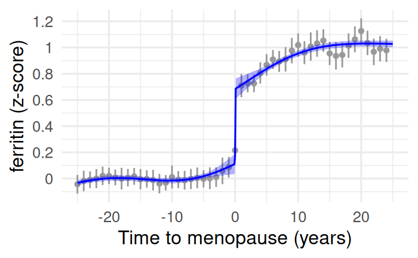

```r
plot(gt)


save=T
if(save)
{
    ggsave(sprintf("%s/results/%s.pdf",outputDir,"fig1d"),gt,width=8,height=6)
    ggsave(sprintf("%s/results/%s.pdf",outputDir,"fig1c"),gage,width=8,height=6)
}
```

#Figure 2 - system by system comparison compute using nhanes_menopause_propensity_score_matching_hrt

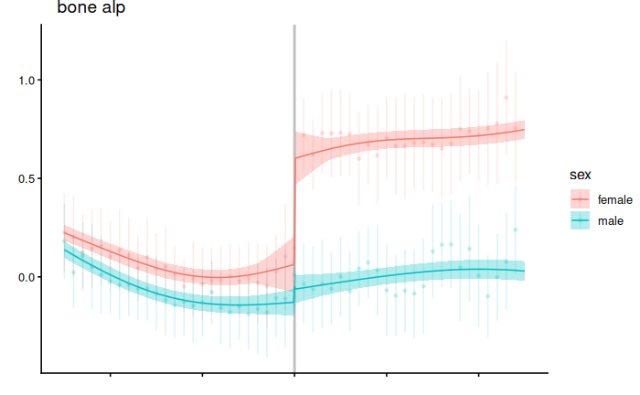

```r
#plotdf = subset(ms[["pr"]],model%in%c("pwLinear","spline","splineJump","GAMSplineGAULSS"))
#plotdf = subset(ms[["pr"]],model%in%c("pwGAULSS","pwSpline","highKSplineJump","highKSpline"))
plotdf = ms[["bestPr"]]
plotdf[,"sex"] = "female"
plotdf = rbind(plotdf[,c("var","x","y","yse","sex")],cbind(msm[["bestPr"]][,c("var","x","y","yse")],sex="male"))
v = unique(plotdf[,"var"])
names(v) = keep_list[v,"prettyname"]
v = v[order(systemCodex[v,"primary"],names(v))]
g = list()
temp = agg
for (j in 1:length(v))
{
  temp[,"y"] = agg[,v[j]]
  temp[,"yse"] = agg[,sprintf("%sse",v[j])]
  g[[j]] = ggplot(subset(plotdf,var==v[j]),aes(x=x,y=y,ymin=y-yse,ymax=y+yse,colour=sex,fill=sex))+
    #geom_vline(xintercept=-20,size=.5,colour="grey85")+
    #geom_vline(xintercept=20,size=.5,colour="grey85")+
    #geom_vline(xintercept=-10,size=.5,colour="grey85")+
    #geom_vline(xintercept=10,size=.5,colour="grey85")+
    geom_vline(xintercept=0,size=1,colour="grey75")+
    labs(x="",y="",title=keep_list[v[j],"prettyname"])+
    geom_pointrange(data=temp,aes(x=t),alpha=.15,size=.1)+
    geom_line()+
    geom_ribbon(alpha=.3,colour=NA)+
    #theme_minimal(base_size=12)+
    theme_classic(base_size=12)+
      theme(
            axis.text.x=element_blank(),
            plot.title.position = "plot", #plot or panel
            plot.title = element_text(hjust = 0.1),
            plot.margin = margin(0, 0, 0, 0),    # remove outer margin
            panel.spacing = unit(0, "lines"),   # remove spacing between panels (if faceted)
            panel.border = element_blank()      # optional: remove panel border)
    )

}
g[[1]]
```

```r
library(cowplot)
gleg = cowplot::get_legend(g[[1]])

for (i in 1:length(g)) g[[i]] = g[[i]] + theme(legend.position="none")

save=F
if(save)
{
  library(gridExtra)
  nrow = 10
  ncol = 9
  layout = matrix(seq_len(nrow*ncol),nrow=nrow,ncol=ncol,byrow=TRUE)

ggsave(sprintf("%s/results/%s.png",outputDir,"menopause_nhanes_systems_legend_bytime"),gleg,width=8,height=6)
    ggsave(sprintf("%s/results/%s.png",outputDir,"menopause_nhanes_systems_bytime"),marrangeGrob(g,nrow=nrow,ncol=ncol,top=NULL,layout_matrix=layout),width=16,height=16*nrow/ncol)
    ggsave(sprintf("%s/results/%s.pdf",outputDir,"menopause_nhanes_systems_bytime"),marrangeGrob(g,nrow=nrow,ncol=ncol,top=NULL,layout_matrix=layout),width=16,height=16*nrow/ncol)
}
```

Fib 2b - delta

```r
bestDelta=read.csv(sprintf("%s/results/nhanes_menopause_model_selection_bestDelta_%s.csv",outputDir,"ac"))
bestDeltaM=read.csv(sprintf("%s/results/nhanes_menopause_model_selection_males_bestDelta_%s.csv",outputDir,"ac"))
beta = bestDelta
if(!isTRUE(all.equal(bestDelta[,"var"],bestDeltaM[,"var"])) | !isTRUE(all.equal(round(bestDelta[,"x"],4),round(bestDeltaM[,"x"],4))) )
{
  stop("females and males not aligned")
}
beta[,"yvsM"]   = bestDelta[,"y"]-bestDeltaM[,"y"]
beta[,"yvsMse"] = sqrt(bestDelta[,"yse"]^2+bestDeltaM[,"yse"]^2)
beta[,"M"]   = bestDeltaM[,"y"]
beta[,"Mse"] = bestDeltaM[,"yse"]
```

basic plot

```r
library(dplyr)
se_median <- function(x, B = 1000,na.rm=T) {
  if(na.rm) x <- na.omit(x)
  n <- length(x)
  boots <- replicate(B, median(sample(x, n, replace = TRUE)))
  sd(boots)  # bootstrap standard error of the median
}
pcut = .05

logi = round(beta[,"x"],3)==3 #how many year delta?
plotdf = data.frame(var=beta[logi,"var"],y=beta[logi,"yvsM"],se=beta[logi,"yvsMse"],p=NA) #looks good
#plotdf = data.frame(var=beta[logi,"var"],y=beta[logi,"y"],se=beta[logi,"yse"],p=NA) #looks good
#plotdf = data.frame(var=beta[logi,"var"],y=beta[logi,"M"],se=beta[logi,"Mse"],p=NA) #lots of false positives

plotdf[,"pz"] =  2*(1-pnorm(abs(plotdf[,"y"])/plotdf[,"se"]))
logi = keep_list[plotdf[,"var"],"group"]=="labs"
logi[is.na(logi)]=F
plotdf = plotdf[logi,]
plotdf[,"system"] = systemCodex[plotdf[,"var"],"primary"]
system = plotdf[,"system"]

#drop duplicates
plotdf = subset(plotdf,!(var%in%c("ferr","platelet","k","na","lactate")))

system = plotdf[,"system"]



plotdf2 = plotdf

#plotdf2[,"padj"] = p.adjust(plotdf2[,"p"],method="BH") #based on E[log(p)]
plotdf2[,"padj"] = p.adjust(plotdf2[,"pz"],method="BH") #based on z test    #looks a little better and makes more sense
#plotdf2[,"padj"] = plotdf2[,"pz"]

print("number significant at pz<0.05:")
```

```
[1] "number significant at pz<0.05:"
```

```r
print(sum(plotdf2[,"pz"] < pcut))
```

```
[1] 57
```

```r
print("fdr adjusted:")
```

```
[1] "fdr adjusted:"
```

```r
print(sum(plotdf2[,"padj"] < pcut))
```

```
[1] 56
```

```r
print("who didn't jump:")
```

```
[1] "who didn't jump:"
```

```r
print(subset(plotdf2, padj >= pcut)[,c("var","system","pz")] )
```

|  | var | system | pz |
| --- | --- | --- | --- |
| 4 | pth | bone | 0.94241313 |
| 12 | fibrinogen | clotting | 0.87506752 |
| 14 | nfl | cognition | 0.93107667 |
| 15 | bmi | glucose metabolism | 0.55950248 |
| 16 | cpeptide | glucose metabolism | 0.97467696 |
| 17 | f_glucose | glucose metabolism | 0.65937144 |
| 18 | glycohemoglobin | glucose metabolism | 0.11747618 |
| 19 | gtt | glucose metabolism | 0.95794833 |
| 20 | insulin | glucose metabolism | 0.11700270 |
| 23 | dhea | gonad | 0.81248882 |

[output cut: 24 more lines]

```r
  #plotdf2 = subset(plotdf2, pz < 0.05)
  plotdf2 = subset(plotdf2, padj < pcut)
  #plotdf2 = subset(plotdf2, p < 0.005) #tuned

  print("range:")
```

```
[1] "range:"
```

```r
  print(range(abs(plotdf2[,"y"]),na.rm=T))
```

```
[1] 0.08979717 1.30837627
```

```r
    labdata = plotdf2[!duplicated(plotdf2[,"system"]),]
  labdata[,"y"] = 1

    systemCols = rep("#7F7F7F",nrow(plotdf2))
  for (i in 1:length(systemCols))
  {
    systemCols[i] = keep_list[as.character(plotdf2[i,"var"]),"colour"]
  }
  breaks = plotdf2[,"system"]
  systemCols = systemCols[!duplicated(breaks)]
  breaks = breaks[!duplicated(breaks)]
  names(systemCols)=breaks

  #system aggregates
  plotdf2[,"absy"] = abs(plotdf2[,"y"])
  sysAgg = aggregate(plotdf2[,c("absy"),drop=F],by=plotdf2[,c("system"),drop=F],median,na.rm=T)
  sysAgg[,"se"] = aggregate(plotdf2[,c("absy"),drop=F],by=plotdf2[,c("system"),drop=F],se_median,na.rm=T)[,"absy"]
  sysAgg[,"y"] = sysAgg[,"absy"]
  #now find central value for each system...
  representatives=plotdf2 %>%
    group_by(system) %>%
    mutate(mean_y = median(absy, na.rm = TRUE)) %>%
    slice_min(order_by = abs(absy - mean_y), n = 1, with_ties = FALSE) %>%
    ungroup()
  representatives=as.data.frame(representatives)
  rownames(representatives) = representatives[,"system"]
  sysAgg[,"var"] = representatives[sysAgg[,"system"],"var"]

  plotdf2 <- plotdf2 %>%
  group_by(system) %>%
  mutate(`systemAve` = median(abs(y), na.rm = TRUE)) %>%
  ungroup()
plotdf2 = as.data.frame(plotdf2)


    #replace var with pretty names
  for (i in 1:nrow(plotdf2)) plotdf2[i,"var"] = keep_list[plotdf2[i,"var"],"prettyname"]
  for (i in 1:nrow(sysAgg)) sysAgg[i,"var"] = keep_list[sysAgg[i,"var"],"prettyname"]

  inds = order(-plotdf2[,"systemAve"],plotdf2[,"system"],-abs(plotdf2[,"y"]))
  plotdf2[,"var"] = factor(plotdf2[,"var"],plotdf2[inds,"var"])

  plotdf2[,"system"] = factor(plotdf2[,"system"],unique(plotdf2[,"system"]))



  g = ggplot(plotdf2,aes(x=var,y=abs(y),ymin=abs(y)-se,ymax=abs(y)+se,fill=system,colour=system))+#,size=abs(slope)))+
    geom_col()+
    #geom_point(colour='black')+
    geom_errorbar(colour="grey",size=1)+
    #geom_label(aes(label=sprintf("%.3f",p)),fill=NA,colour="black")+

    #geom_label(data=labdata,aes(label=system),fill=NA,show.legend = F)+
    geom_pointrange(data=sysAgg,colour="black",size=1,linewidth=1.5)+
    #labs(x="",y=bquote(tau),title="Time when changes start")+
    #labs(x="",y="Jump size (z-score)")+
    labs(x="",y=bquote("|"*Delta~"female - "*Delta~"male| (z-score)"))+
    scale_color_manual(values = systemCols)+
    scale_fill_manual( values = systemCols)+
    #scale_y_continuous(limits=c(0,15,by=2.5))+
    #scale_y_continuous(breaks=seq(5,15,by=2.5))+ #truncate coords
    #coord_cartesian(ylim = c(5, 16))+ #truncate coords
    theme_minimal(base_size=20)+
    theme(axis.text.x = element_text(angle=90,vjust=.5),
          #axis.title.y = element_text(angle=0,vjust=.58),
          legend.title=element_blank(),
          legend.position="none")

  addLabels=F #will put them on later in Gimp
if(addLabels)
{
  g =g + geom_label_repel(data=labdata,aes(label=system),fill=NA,show.legend = F,size=10,fontface="bold")
}


print(sysAgg[sort.list(-sysAgg[,"absy"]),])
```

|  | system | absy | se | y | var |
| --- | --- | --- | --- | --- | --- |
| 4 | gonad | 0.74653634 | 0.081025496 | 0.74653634 | e1 |
| 2 | bone mass | 0.54103449 | 0.081923590 | 0.54103449 | l1 bmd |
| 10 | metal | 0.46192994 | 0.036159486 | 0.46192994 | cobalt |
| 1 | bone | 0.42764662 | 0.084407103 | 0.42764662 | calcium |
| 13 | rbc | 0.34057314 | 0.079531976 | 0.34057314 | rdw |
| 9 | liver | 0.31962663 | 0.048586384 | 0.31962663 | albumin |
| 6 | iron | 0.29097836 | 0.126500438 | 0.29097836 | transferrin sat. |
| 8 | lipid metabolism | 0.24144272 | 0.034084662 | 0.24144272 | apob |
| 7 | kidney | 0.22852074 | 0.055961313 | 0.22852074 | cystatin |
| 12 | muscle | 0.20575176 | 0.053067464 | 0.20575176 | ck |

[output cut: 4 more lines]

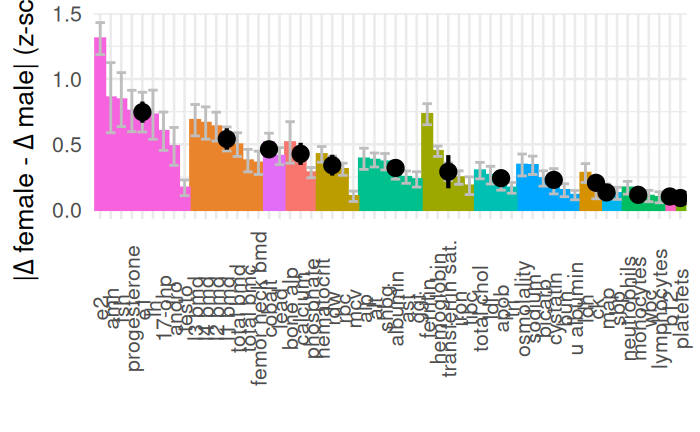

```r
#g = g +  coord_cartesian(clip = "off")

#g = g + coord_flip()



g
save=T
if(save)
{

      #ggsave(sprintf("%s/results/menopause_nhanes_beta_barplot_%s.pdf",outputDir,opts),do.call(grid.arrange, c(g, nrow=6,ncol=6)), width=16,height=16)
  ggsave(sprintf("%s/results/menopause_nhanes_fig2b_%s.pdf",outputDir,opts),g, width=16,height=6)
  ggsave(sprintf("%s/results/menopause_nhanes_fig2b_%s.png",outputDir,opts),g, width=16,height=6)

}
```

Fib 2c nhanes vs clalit

```r
yoavJumps = read.csv(sprintf("%s/data/COMPREHENSIVE_all_models_summary_with_nhanes_names_yoav.csv",outputDir))
yoavJumps = subset(yoavJumps,nhanes_name!="")
yoavJumps[,"var"] = yoavJumps[,"nhanes_name"]
rownames(yoavJumps)=yoavJumps[,"var"]

#check overlap #BMI is MIA
#setdiff(rownames(yoavJumps),beta[,"var"])
#setdiff(beta[,"var"],rownames(yoavJumps))
```

```r
logi = round(beta[,"x"],3)==3 #how many year delta?
logi[is.na(logi)]=F
plotdf = data.frame(var=beta[logi,"var"],y=beta[logi,"y"],se=beta[logi,"yse"],p=NA) #looks good and is
rownames(plotdf)=plotdf[,"var"]

plotdf[,"clalit"] = NA
v = intersect(yoavJumps[,"var"],plotdf[,"var"])
#v = setdiff(v,c("fsh","e2","lh","dhea","progsterone","andro","hprog","test","e1")) #specific drops
print(sprintf("concordant between systems (N=%d)",length(v)))
```

```
[1] "concordant between systems (N=57)"
```

```r
print(v)
```

```
 [1] "bmi"             "fibrinogen"      "platelets"       "crp"             "ferritin"        "folate"
 [7] "iron"            "b12"             "albumin"         "alt"             "ast"             "bilirubin"
[13] "ggt"             "shbg"            "total_chol"      "hdl"             "ldl"             "f_glucose"
[19] "glycohemoglobin" "insulin"         "tri"             "bicarb"          "ck"              "ldh"
[25] "pth"             "alp"             "phosphate"       "osmolality"      "sodium"          "bun"
[31] "hematocrit"      "hemoglobin"      "mcv"             "rbc"             "rdw"             "calcium"
[37] "scr"             "u_creatinine"    "potassium"       "hprog"           "andro"           "dhea"
[43] "e2"              "fsh"             "lh"              "progsterone"     "test"            "ft3"
[49] "tt3"             "ft4"             "thyroglobulin"   "tsh"             "eosinophils"     "lymphocytes"
[55] "monocytes"       "neutrophils"     "wbc"
```

```r
plotdf[v,"clalit"] = yoavJumps[v,"linear_time_3_mean"]
plotdf[v,"clalitse"] = yoavJumps[v,"linear_time_3_sd"]
plotdf[,"clalitmin"] = plotdf[,"clalit"]-plotdf[,"clalitse"]
plotdf[,"clalitmax"] = plotdf[,"clalit"]+plotdf[,"clalitse"]


#rescale z for jumps? (some vars z scores that aren't right)
rescaleJumps=F
if(rescaleJumps)
{
  for (i in 1:nrow(plotdf))
  {
    m = mean(subset(Xf,RIDAGEYR>=25 & RIDAGEYR <= 45)[,plotdf[i,"var"]],na.rm=T)
    s = sd(subset(Xf,RIDAGEYR>=25 & RIDAGEYR <= 45)[,plotdf[i,"var"]],na.rm=T)
    print(sprintf("m: %.2f, s: %.2f",m,s))
    plotdf[i,"y"] = (plotdf[i,"y"]-m)/s
    plotdf[i,"se"] = plotdf[i,"se"]/s
  }
}

plotdf[,"system"] = systemCodex[plotdf[,"var"],"primary"]

print(cor.test(plotdf[,"y"],plotdf[,"clalit"],use='pairwise.complete'))
```

```
    Pearson's product-moment correlation

data:  plotdf[, "y"] and plotdf[, "clalit"]
t = 15.714, df = 55, p-value < 2.2e-16
alternative hypothesis: true correlation is not equal to 0
95 percent confidence interval:
 0.8422409 0.9427559
sample estimates:
      cor
0.9043412
```

```r
print(summary(lm(y~clalit,plotdf)))
```

```
Call:
lm(formula = y ~ clalit, data = plotdf)

Residuals:
     Min       1Q   Median       3Q      Max
-0.65037 -0.05300  0.01338  0.08881  0.30681

Coefficients:
            Estimate Std. Error t value Pr(>|t|)
(Intercept) -0.07825    0.02266  -3.453  0.00108 **
clalit       0.63260    0.04026  15.714  < 2e-16 ***
---
Signif. codes:  0 ‘***’ 0.001 ‘**’ 0.01 ‘*’ 0.05 ‘.’ 0.1 ‘ ’ 1

Residual standard error: 0.1534 on 55 degrees of freedom
  (33 observations deleted due to missingness)
Multiple R-squared:  0.8178,    Adjusted R-squared:  0.8145
F-statistic: 246.9 on 1 and 55 DF,  p-value: < 2.2e-16
```

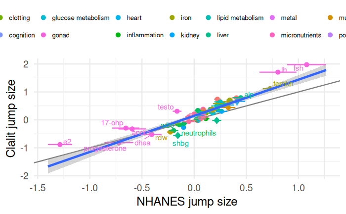

```r
systemCols = rep("#7F7F7F",nrow(plotdf))
for (i in 1:length(systemCols))
{
  systemCols[i] = keep_list[as.character(plotdf[i,"var"]),"colour"]
}
breaks = plotdf[,"system"]
systemCols = systemCols[!duplicated(breaks)]
breaks = breaks[!duplicated(breaks)]
names(systemCols)=breaks

plotdf[,"prettyname"] = keep_list[plotdf[,"var"],"prettyname"]

g= ggplot(plotdf,aes(y=clalit,ymin=clalitmin,ymax=clalitmax,x=y,xmin=y-se,xmax=y+se,label=prettyname,colour=system))+
  geom_abline(slope=1,intercept=0,colour='grey50')+
  geom_point()+
  geom_errorbar(width=0)+
  geom_errorbarh(height=0)+
  geom_smooth(method="lm",aes(y=clalit,x=y),inherit.aes=F,fullrange=TRUE)+
  geom_text_repel(show.legend=F,size=4,max.overlaps=15,seed=1)+
  scale_colour_manual(values=systemCols)+
  #labs(x="NHANES jump size from method 1",y="Clalit jump size from method 2")+
  labs(x="NHANES jump size",y="Clalit jump size")+
  guides(colour = guide_legend(ncol = 10))+
  theme_minimal(base_size=18)+
  theme(legend.position="top",
         legend.key.width = unit(3, 'mm'),
        legend.text=element_text(size=10),
        legend.title=element_blank())

g

save=T
if(save)
{
  library(cowplot)
  gleg = ggdraw(cowplot::get_legend(g))
  g = g +theme(legend.position = "none")
    ggsave(sprintf("%s/results/menopause_nhanes_fig2c_leg.pdf",outputDir),gleg, width=16,height=4)
  ggsave(sprintf("%s/results/menopause_nhanes_fig2c.pdf",outputDir),g, width=8,height=7)
    ggsave(sprintf("%s/results/menopause_nhanes_fig2c.png",outputDir),g, width=8,height=7)
}
```

#Figure 3 - HRT correlation with jupm

```r
df = read.csv(sprintf("%s/results/menopause_labs_hrt_propensity_score_matched.csv",outputDir),row.names=1)
  print("correlation with jump:")
```

```
[1] "correlation with jump:"
```

```r
  logi = round(beta[,"x"],3)==3 #how many year delta?
  logi[is.na(logi)]=F
  plotdf = data.frame(var=beta[logi,"var"],y=beta[logi,"yvsM"],se=beta[logi,"yvsMse"],p=NA)
  plotdf = data.frame(var=beta[logi,"var"],y=beta[logi,"y"],se=beta[logi,"yse"],p=NA)
  rownames(plotdf)=plotdf[,"var"]

  plotdf[,"system"] = keep_list[plotdf[,"var"],"primary"]


plotdf[,"deltahrt"]=-df[rownames(plotdf),"delta"]
plotdf[,"deltahrtse"]=df[rownames(plotdf),"deltase"]
#drop gonads
plotdf = subset(plotdf,system!="gonad")
print("overall cor:")
```

```
[1] "overall cor:"
```

```r
print(cor.test(plotdf[,"y"],plotdf[,"deltahrt"],use='complete'))
```

```
    Pearson's product-moment correlation

data:  plotdf[, "y"] and plotdf[, "deltahrt"]
t = 6.1761, df = 68, p-value = 4.175e-08
alternative hypothesis: true correlation is not equal to 0
95 percent confidence interval:
 0.4242566 0.7314167
sample estimates:
      cor
0.5994699
```

```r
print("excluding iron & iron:")
```

```
[1] "excluding iron & iron:"
```

```r
logi = !(plotdf[,"system"] %in%c("rbc","iron"))
print(cor.test(plotdf[logi,"y"],plotdf[logi,"deltahrt"],use='complete'))
```

```
    Pearson's product-moment correlation

data:  plotdf[logi, "y"] and plotdf[logi, "deltahrt"]
t = 6.8638, df = 59, p-value = 4.599e-09
alternative hypothesis: true correlation is not equal to 0
95 percent confidence interval:
 0.4980708 0.7862178
sample estimates:
      cor
0.6663188
```

```r
print("excluding iron & iron & inflammation (CRP and HS-CRP):")
```

```
[1] "excluding iron & iron & inflammation (CRP and HS-CRP):"
```

```r
logi = !(plotdf[,"system"] %in%c("rbc","iron","inflammation"))
print(cor.test(plotdf[logi,"y"],plotdf[logi,"deltahrt"],use='complete'))
```

```
    Pearson's product-moment correlation

data:  plotdf[logi, "y"] and plotdf[logi, "deltahrt"]
t = 7.0381, df = 58, p-value = 2.53e-09
alternative hypothesis: true correlation is not equal to 0
95 percent confidence interval:
 0.5132272 0.7955268
sample estimates:
      cor
0.6787027
```

```r
print("excluding bone:")
```

```
[1] "excluding bone:"
```

```r
logi = !(plotdf[,"system"] %in%c("bone","bone mass"))
print(cor.test(plotdf[logi,"y"],plotdf[logi,"deltahrt"],use='complete'))
```

```
    Pearson's product-moment correlation

data:  plotdf[logi, "y"] and plotdf[logi, "deltahrt"]
t = 2.7297, df = 59, p-value = 0.008343
alternative hypothesis: true correlation is not equal to 0
95 percent confidence interval:
 0.09068416 0.54105476
sample estimates:
     cor
0.334858
```

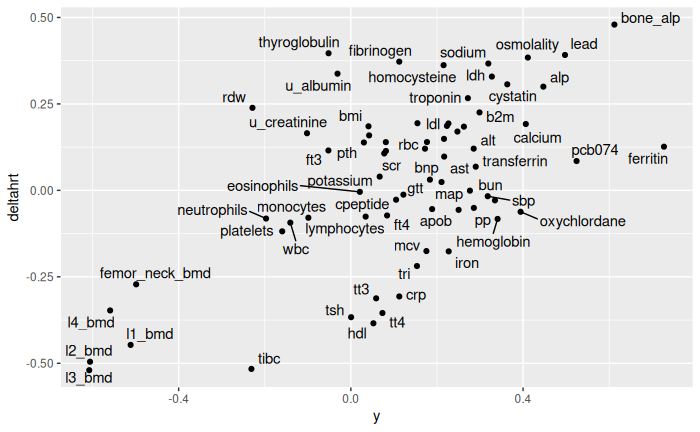

```r
ggplot(plotdf,aes(x=y,y=deltahrt,label=var))+
  geom_point()+
  geom_text_repel(show.legend = F)
```

csv file for supplemental on HRT

```r
temp = df
temp[,"prettyname"] = keep_list[temp[,"var"],"prettyname"]
temp[,"system"] = keep_list[temp[,"var"],"primary"]

print("significance:")
```

```
[1] "significance:"
```

```r
print(sprintf("total tests: %.0f",sum(temp[,"padj"],na.rm=T)))
```

```
[1] "total tests: 14"
```

```r
print(sprintf("padj < .05: %.0f",sum(temp[,"padj"] < .05,na.rm=T)))
```

```
[1] "padj < .05: 37"
```

```r
print(sprintf("p    < .10: %.0f",sum(temp[,"pwilcox"] < .1,na.rm=T)))
```

```
[1] "p    < .10: 48"
```

```r
print(sprintf("p    < .10 & padj > .05: %.0f",sum(temp[,"pwilcox"] < .1 & temp[,"padj"] >= .05,na.rm=T)))
```

```
[1] "p    < .10 & padj > .05: 11"
```

```r
#fix p values to look sane
logi = temp[,"pwilcox"] < .01
logi[is.na(logi)]=F
#temp[logi,"pwilcox"] = sprintf("10^%.0f",round(log(df[logi,"pwilcox"],10)))
temp[logi,"pwilcox"] = sprintf("'%.0e",df[logi,"pwilcox"])
temp[!logi,"pwilcox"] = sprintf("'%.2f",df[!logi,"pwilcox"])
logi = temp[,"padj"] < .01
logi[is.na(logi)]=F
#temp[logi,"padj"] = sprintf("10^%.0f",round(log(df[logi,"padj"],10)))
temp[logi,"padj"] = sprintf("'%.0e",df[logi,"padj"])
temp[!logi,"padj"] = sprintf("'%.2f",df[!logi,"padj"])

#drop any with insufficient N
temp = subset(temp,!is.na(delta))

#round deltas
#temp[,"delta"] = round(temp[,"delta"],3)
#temp[,"deltase"] = round(temp[,"deltase"],3)
temp[,"delta"]   = sprintf("'%.3f",temp[,"delta"])
temp[,"deltase"] = sprintf("'%.3f",temp[,"deltase"])

#sort by name
temp = temp[sort.list(temp[,"prettyname"]),]



write.csv(temp[,c("prettyname","system","N","delta","deltase","pwilcox","padj")],sprintf("%s/results/nhanes_supplemental_hrt.csv",outputDir),row.names=F)
```

```r
colours=c("deepskyblue1","purple3","deepskyblue3")
names(colours)=c("Premenopause","MRT","No MRT")
mustHavePr = TRUE
useImputed=F #I have doubts about using this - it generally isn't used by the imputation models so its association will be broken
acMatch=TRUE #only permits matching using non-imputed values
if(acMatch)
{
  matchRatio=1
  preMatchRatio=1
  opts = "ac"
} else
{
  matchRatio=3
  preMatchRatio = 4
  opts = "imp"
}
  agg= read.csv(sprintf("%s/results/nhanes_menopause_propensity_score_labs_agg_%s.csv",outputDir,opts))
  pr = read.csv(sprintf("%s/results/nhanes_menopause_propensity_score_labs_pr_%s.csv",outputDir,opts))

v = intersect(colnames(agg),subset(keep_list,group=="labs")[,"variable"])
names(v) = keep_list[v,"prettyname"]

g = list()
keepMe = rep(T,length(v))
for (j in 1:length(v))
{


  agg[,"y"]    = agg[,sprintf("%s",v[j])]
  agg[,"ymin"] = agg[,sprintf("%smin",v[j])]
  agg[,"ymax"] = agg[,sprintf("%smax",v[j])]
  pr[,"y"]     = pr[,sprintf("%s",v[j])]
  pr[,"ymin"]  = pr[,sprintf("%smin",v[j])]
  pr[,"ymax"]  = pr[,sprintf("%smax",v[j])]


  #drop anything without an errorbar
agg[is.na(agg[,"ymin"]) | is.na(agg[,"ymax"]),"y"] = NA

  if(all(is.na(subset(agg,group=="MRT")[,"y"])) | all(is.na(subset(agg,group=="No MRT")[,"y"])) |
     all(is.na(subset(agg,group=="MRT")[,"ymin"])) | all(is.na(subset(agg,group=="No MRT")[,"ymin"])) |
     all(is.na(subset(agg,group=="MRT")[,"ymax"])) | all(is.na(subset(agg,group=="No MRT")[,"ymax"])) |
    all(is.na(subset(pr,group=="MRT")[,"y"])) | all(is.na(subset(pr,group=="No MRT")[,"y"])) # | all(is.na(subset(pr,group=="Premenopause")[,"y"]))
     )
  {
    warning(sprintf("skipping %s, not enough data",v[j]))
    keepMe[j]=F
    next
  }

  if(mustHavePr)
  {
    if(all(is.na(subset(pr,group=="MRT")[,"y"])) | all(is.na(subset(pr,group=="No MRT")[,"y"])) |
     all(is.na(subset(pr,group=="Premenopause")[,"ymin"])) |
    all(is.na(subset(pr,group=="MRT")[,"y"])) | all(is.na(subset(pr,group=="No MRT")[,"y"]))
     )
    {
      warning(sprintf("skipping %s, not enough data",v[j]))
      keepMe[j]=F
      next
   }
  }

  g[[j]] = ggplot(agg,aes(x=time_since_menopause,y=y,ymin=ymin,ymax=ymax,colour=group,fill=group,shape=group))+
            geom_vline(xintercept=0,size=1,colour="grey75")+
  geom_pointrange(size=.1,alpha=.25)+
  geom_line(data=pr)+
  geom_ribbon(data=pr,colour=NA,alpha=.2)+
  scale_colour_manual(breaks=names(colours),values=colours)+
  scale_fill_manual(breaks=names(colours),values=colours)+
  labs(x="Time to menopause (years)",y=names(v)[j],title=names(v)[j])+
  theme_minimal(base_size=8)+
  theme(legend.title=element_blank())
}
print("drops:")
```

```
[1] "drops:"
```

```r
print(v[!keepMe])
```

```
      total bmc       total bmd      fibrinogen             nfl           hscrp            shbg          cobalt
    "total_bmc"     "total_bmd"    "fibrinogen"           "nfl"         "hscrp"          "shbg"        "cobalt"
       selenium          folate    folate (rbc)              ck             ft3             ft4   thyroglobulin
     "selenium"        "folate"    "folate_rbc"            "ck"           "ft3"           "ft4" "thyroglobulin"
            tsh             tt3             tt4
          "tsh"           "tt3"           "tt4"
```

```r
g = g[keepMe]



systemsOutputDir = sprintf("%s/results",outputDir)
  gleg = ggdraw(cowplot::get_legend(g[[1]]))
for (i in 1:length(g)) g[[i]] = g[[i]] + theme(legend.position="none")
save=F
if(save)
{
  library(marrangeGrob)




  includeLeg=FALSE
  gm = g
  ncol = 9
  nrow = 1
  while(nrow*ncol < length(gm)+1*includeLeg)
  {
    nrow=nrow+1
  }
  for(jj in 1:length(gm))
  {
    gm[[jj]] = gm[[jj]] + labs(x="",y="")+
      #theme_minimal(base_size=12)+
      theme_classic(base_size=12)+
      theme(
            axis.text.x=element_blank(),
            plot.title.position = "plot", #plot or panel
            plot.title = element_text(hjust = 0.1),
            plot.margin = margin(0, 0, 0, 0),    # remove outer margin
            panel.spacing = unit(0, "lines"),   # remove spacing between panels (if faceted)
            panel.border = element_blank()      # optional: remove panel border)
    )
  }
    gleg = ggdraw(cowplot::get_legend(gm[[length(gm)]]))
  #saveRDS(list(g=gm,leg=gleg),sprintf("%s/%s_%s.rds",systemsOutputDir,"menopause_nhanes_systems_bytime",opts))



  inds = 1:(nrow*ncol-1)
  inds = inds[inds<=length(gm)]
  layout = matrix(seq_len(nrow*ncol),nrow=nrow,ncol=ncol,byrow=TRUE)
  #adjust layout to leave splot for scatter plot:
  #layout[6,8:9] = Inf
  #layout[7,] = 53:61

    g = gm
    for (jj in 1:length(g)) g[[jj]] = g[[jj]]+theme(legend.position="none")

    if(includeLeg)
    {
      g[[length(g)+1]] = gleg
    } else ggsave(sprintf("%s/%s_legend.png",systemsOutputDir,"fig3_hrt_leg"),gleg,width=8,height=6)
    #ggsave(sprintf("%s/%s.png",systemsOutputDir,"menopause_nhanes_hrt_bytime"),marrangeGrob(g,nrow=nrow,ncol=ncol,top=NULL,layout_matrix=layout),width=16,height=16*nrow/ncol)
    ggsave(sprintf("%s/%s.pdf",systemsOutputDir,"fig3_hrt"),marrangeGrob(g,nrow=nrow,ncol=ncol,top=NULL,layout_matrix=layout),width=16,height=16*nrow/ncol)

}
```

significance:

```r
print(data.frame(var=v,p=df[v,"padj"],sig=df[v,"padj"] < .05))
```

|  | var | p | sig |
| --- | --- | --- | --- |
| bone alp | bone_alp | 1.743942e-07 | TRUE |
| calcium | calcium | 9.437873e-04 | TRUE |
| phosphate | phosphate | 5.811726e-04 | TRUE |
| pth | pth | 7.423414e-02 | FALSE |
| femor neck bmd | femor_neck_bmd | 1.821076e-01 | FALSE |
| l1 bmd | l1_bmd | 2.161591e-02 | TRUE |
| l2 bmd | l2_bmd | 1.632823e-02 | TRUE |
| l3 bmd | l3_bmd | 1.289333e-02 | TRUE |
| l4 bmd | l4_bmd | 1.018936e-02 | TRUE |
| total bmc | total_bmc | NA | NA |

[output cut: 70 more lines]

#Figure 4 - change point subset(ms$prsd,var==“amh” & model==“pwGAULSS”) load in premenopause models

```r
source(sprintf("%s/menopause_script.R",outputDir),verbose=0)
load=T
save=T

opts="ac"
#opts = "mi"
modelSet = 1 #1 or 2
if (modelSet > 1) opts = sprintf("%s_modelSet%02d",opts,modelSet)


file=sprintf("%s/results/nhanes_menopause_premenopause_model_selection_%s.rds",outputDir,opts)
deltaFile=sprintf("%s/results/nhanes_menopause_premenopause_model_selection_delta_%s.csv",outputDir,opts)
predFile=sprintf("%s/results/nhanes_menopause_premenopause_model_selection_pred_%s.csv",outputDir,opts)
bestDeltaFile=sprintf("%s/results/nhanes_menopause_premenopause_model_selection_bestDelta_%s.csv",outputDir,opts)
bestPredFile=sprintf("%s/results/nhanes_menopause_premenopause_model_selection_bestPred_%s.csv",outputDir,opts)


if(modelSet==1)
{
  refModels=1:2
  models = list(GAULSS=GAMSplineGAULSS, HighKGAULSS=HighKGAMSplineGAULSS2)  #high K looks same
} else
{
  refModels=1:3
  models = list(linear=LM,spline=GAMSpline,GAULSS=GAMSplineGAULSS)
}
if(file.exists(file) & load)
{
  mscp=readRDS(file)
} else
{
  print("files not found")
  stop("please compute using nhanes_premenopause_model_selection.Rmd")
}
```

```r
yoavTimescales = read.csv(sprintf("%s/data/yoav_bar_plot_data_before_menopause.csv",outputDir))
rownames(yoavTimescales)=yoavTimescales[,"var"]

yoavE2  = read.csv(sprintf("%s/data/yoav_bootstrap_statistics_ref_ages_25_45_Estradiol_female.csv",outputDir))
yoavFSH = read.csv(sprintf("%s/data/yoav_bootstrap_statistics_ref_ages_25_45_FSH_female.csv",outputDir))
```

```r
library(KernSmooth) #convenient curvature - gives same result as discrete
g  = list()
g[[1]] = ggplot(subset(mscp$pr,var=="amh" & model=="GAULSS" & x < 0),aes(x=x,y=y,ymin=y-yse,ymax=y+yse))+
  geom_line()+
  geom_ribbon(alpha=.25,colour=NA)+
  labs(x="Time to menopause (years)",y="z-score",title="a) AMH")+
  theme_classic()

#rescale z for jumps? (some vars z scores that aren't right)
rescaleJumps=F
mfsh = 0
sfsh = 1
me2 =  0
se2 = 1
if(rescaleJumps)
{
  mfsh = mean(subset(Xf, RIDAGEYR>=25 & RIDAGEYR <= 45)[,"fsh"],na.rm=T)
  sfsh = sd(subset(Xf,   RIDAGEYR>=25 & RIDAGEYR <= 45)[,"fsh"],na.rm=T)
  me2 =  mean(subset(Xf, RIDAGEYR>=25 & RIDAGEYR <= 45)[,"e2"],na.rm=T)
  se2 =  sd(subset(Xf,   RIDAGEYR>=25 & RIDAGEYR <= 45)[,"e2"],na.rm=T)
}

g[[2]] = ggplot(subset(mscp$pr,var=="fsh" & model=="GAULSS" & x < 0),aes(x=x,y=(y-mfsh)/sfsh,ymin=(y-mfsh-yse)/sfsh,ymax=(y-mfsh+yse)/sfsh))+
  geom_line()+
  geom_ribbon(alpha=.25,colour=NA)+
  labs(x="Time to menopause (years)",y="z-score",title="b) FSH")+
  theme_classic()


g[[3]] = ggplot(subset(mscp$pr,var=="e2" & model=="GAULSS" & x < 0),aes(x=x,y=(y-me2)/se2,ymin=(y-me2-yse)/se2,ymax=(y-me2+yse)/se2))+
  geom_line()+
  geom_ribbon(alpha=.25,colour=NA)+
  labs(x="Time to menopause (years)",y="z-score",title="c) E2")+
  theme_classic()

temp = subset(mscp$pr,var=="amh" & model=="GAULSS" & x < 0)
grad = locpoly(x=temp[,"x"],y=temp[,"y"],drv=2,bandwidth = 0.1,gridsize = nrow(temp))
amhTime = grad$x[which.max(abs(grad$y))]
#plot(grad3$x,grad3$y,main="AMH")
#points(temp[-c(1,nrow(temp)),"x"],diff(diff(temp[,"y"])/diff(temp[,"x"]))/diff(temp[-1,"x"]),col=2,pch=2) #same as manual
g[[4]] = ggplot(data.frame(x=grad$x,y=grad$y*10^2),aes(x=x,y=y))+
  geom_abline(slope=0,intercept=0,colour="grey75")+
  geom_line()+
  labs(x="Time to menopause (years)",y=bquote("z-score/decade"^2),title="d) AMH Acceleration")+
  theme_classic()

temp = subset(mscp$pr,var=="fsh" & model=="GAULSS" & x < 0)
grad = locpoly(x=temp[,"x"],y=temp[,"y"],drv=2,bandwidth = 0.1,gridsize = nrow(temp))
#plot(grad3$x,grad3$y,main="AMH")
#points(temp[-c(1,nrow(temp)),"x"],diff(diff(temp[,"y"])/diff(temp[,"x"]))/diff(temp[-1,"x"]),col=2,pch=2) #same as manual
g[[5]] = ggplot(data.frame(x=grad$x,y=grad$y*10^2),aes(x=x,y=y))+
  geom_abline(slope=0,intercept=0,colour="grey75")+
  geom_line()+
  labs(x="Time to menopause (years)",y=bquote("z-score/decade"^2),title="e) FSH Acceleration")+
  theme_classic()


temp = subset(mscp$pr,var=="e2" & model=="GAULSS" & x < 0)
grad = locpoly(x=temp[,"x"],y=temp[,"y"],drv=2,bandwidth = 0.1,gridsize = nrow(temp))
#plot(grad3$x,grad3$y,main="AMH")
#points(temp[-c(1,nrow(temp)),"x"],diff(diff(temp[,"y"])/diff(temp[,"x"]))/diff(temp[-1,"x"]),col=2,pch=2) #same as manual
g[[6]] = ggplot(data.frame(x=grad$x,y=grad$y*10^2),aes(x=x,y=y))+
  geom_abline(slope=0,intercept=0,colour="grey75")+
  geom_line()+
  labs(x="Time to menopause (years)",y=bquote("z-score/decade"^2),title="f) E2 Acceleration")+
  theme_classic()

#SD
g[[7]] = ggplot(subset(mscp$prsd,var=="amh" & model=="GAULSS" & x < 0),aes(x=x,y=y,ymin=y-yse,ymax=y+yse))+
  geom_line()+
  geom_ribbon(alpha=.25,colour=NA)+
  labs(x="Time to menopause (years)",y="STD (z-score)",title="g) AMH STD")+
  theme_classic()

g[[8]] = ggplot(subset(mscp$prsd,var=="fsh" & model=="GAULSS" & x < 0),aes(x=x,y=y,ymin=y-yse,ymax=y+yse))+
  geom_line()+
  geom_ribbon(alpha=.25,colour=NA)+
  labs(x="Time to menopause (years)",y="STD (z-score)",title="h) FSH STD")+
  theme_classic()


g[[9]] = ggplot(subset(mscp$prsd,var=="e2" & model=="GAULSS" & x < 0),aes(x=x,y=y,ymin=y-yse,ymax=y+yse))+
  geom_line()+
  geom_ribbon(alpha=.25,colour=NA)+
  labs(x="Time to menopause (years)",y="STD (z-score)",title="i) E2 STD")+
  theme_classic()


addYoav=TRUE
addOff=F #fsh for e2 and e2 for fsj
if(addYoav)
{
  for (j in c(1,4,7))
  {
    addMe = data.frame(yoav=yoavTimescales["fsh","change_point_position"],yoavlow=yoavTimescales["fsh","error_min"],yoavhigh=yoavTimescales["fsh","error_max"])
      g[[j+1]] = g[[j+1]] + geom_vline(data=addMe,aes(xintercept=yoav),colour="purple")+geom_rect(data=addMe,aes(xmin=yoavlow,xmax=yoavhigh,ymin=-Inf,ymax=Inf),alpha=.15,inherit.aes=F,fill="purple")

    if(addOff)
    {
      g[[j+2]] = g[[j+2]] + geom_vline(data=addMe,aes(xintercept=yoav),colour="purple",lty=2)+geom_rect(data=addMe,aes(xmin=yoavlow,xmax=yoavhigh,ymin=-Inf,ymax=Inf),alpha=.15,inherit.aes=F,fill="purple")
    }

      addMe = data.frame(yoav=yoavTimescales["e2","change_point_position"],yoavlow=yoavTimescales["e2","error_min"],yoavhigh=yoavTimescales["e2","error_max"])

      g[[j+2]] = g[[j+2]] +  geom_vline(data=addMe,aes(xintercept=yoav),colour="purple")+geom_rect(data=addMe,aes(xmin=yoavlow,xmax=yoavhigh,ymin=-Inf,ymax=Inf),alpha=.25,inherit.aes=F,fill="purple")

      if(addOff)
      {
        g[[j+1]] = g[[j+1]] + geom_vline(data=addMe,aes(xintercept=yoav),colour="purple",lty=2)+geom_rect(data=addMe,aes(xmin=yoavlow,xmax=yoavhigh,ymin=-Inf,ymax=Inf),alpha=.25,inherit.aes=F,fill="purple")
      }
  }
}

addYoavLine=F
if(addYoavLine)
{
  g[[2]] = g[[2]] + geom_line(data=yoavFSH,aes(x=year,y=mean),colour="purple",inherit.aes=F)+geom_ribbon(data=yoavFSH,aes(x=year,y=mean,ymin=mean-std_dev,ymax=mean+std_dev),alpha=.25,colour=NA,fill="purple",inherit.aes=F)

  g[[3]] = g[[3]] + geom_line(data=yoavE2,aes(x=year,y=mean),colour="purple",inherit.aes=F)+geom_ribbon(data=yoavE2,aes(x=year,y=mean,ymin=mean-std_dev,ymax=mean+std_dev),alpha=.25,colour=NA,fill="purple",inherit.aes=F)
}

addYoavToAMH=F
if(addYoavToAMH)
{
  for (j in c(1,4,7))
  {
    addMe = data.frame(yoav=yoavTimescales[c("fsh","e2"),"change_point_position"],yoavlow=yoavTimescales[c("fsh","e2"),"error_min"],yoavhigh=yoavTimescales[c("fsh","e2"),"error_max"])
      g[[j]] = g[[j]] + geom_vline(data=addMe,aes(xintercept=yoav),colour="purple",lty=2)+geom_rect(data=addMe,aes(xmin=yoavlow,xmax=yoavhigh,ymin=-Inf,ymax=Inf),alpha=.15,inherit.aes=F,fill="purple")

  }
}

addAMHLine=F #weird
if(addYoavToAMH)
{
  for (j in c(1,4,7))
  {
    addMe = data.frame(y=amhTime)
      g[[j]] = g[[j]] + geom_vline(data=addMe,aes(xintercept=y),colour="black")

  }
}


layout = matrix(c(1:length(g),rep(NA,9-length(g))),nrow=3,ncol=3,byrow=TRUE)
marrangeGrob(g,nrow=3,ncol=3,top=NULL,layout_matrix=layout)
```

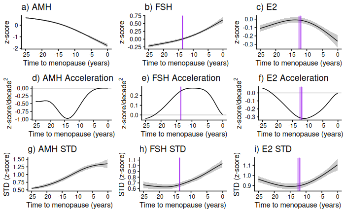

```r
save=TRUE
if(save)
{
      ggsave(sprintf("%s/results/fig4cp.pdf",outputDir),marrangeGrob(g,nrow=3,ncol=3,top=NULL,layout_matrix=layout),width=12,height=9)
      ggsave(sprintf("%s/results/fig4cp.png",outputDir),marrangeGrob(g,nrow=3,ncol=3,top=NULL,layout_matrix=layout),width=12,height=9)
}
```

#Outcome summary

```r
temp = read.csv(sprintf("%s/data/nhanes_clinical_variable_summary.csv",outputDir))

print(head(temp))
```

|  | prettyname | primary | N | nhanes | description | notes |
| --- | --- | --- | --- | --- | --- | --- |
| 1 | adl 0.25 mile | functional | 22459 | PFQ061B | Walking for a quarter mile difficulty | any reported difficulty |
| 2 | adl 10 steps | functional | 22458 | PFQ061C | Walking up ten steps difficulty | any reported difficulty |
| 3 | adl bed-up | functional | 24944 | PFQ061J | Getting in and out of bed difficulty | any reported difficulty |
| 4 | adl chair-up | functional | 24943 | PFQ061I | Standingup from armless chair difficulty | any reported difficulty |
| 5 | adl cross room | functional | 24945 | PFQ061H | Walking between rooms on same floor | any reported difficulty |
| 6 | adl crouching | functional | 24945 | PFQ061D | Stooping, crouching, kneeling difficulty | any reported difficulty |

#Figure 5 - system by system outcomes load cross-validated outcome models

```r
source(sprintf("%s/menopause_script.R",outputDir),verbose=0)
load=T
save=T


opts = "ac"
#opts = "ac_hasStatus" #known menopause status only #slightly sharper at t=0
modelSet = 2 #1 or 2
if (modelSet > 1) opts = sprintf("%s_modelSet%02d",opts,modelSet)

file=sprintf("%s/results/nhanes_menopause_binary_outcome_model_selection_%s.rds",outputDir,opts)
filem=sprintf("%s/results/nhanes_menopause_binary_outcome_model_selection_males_%s.rds",outputDir,opts)


if(modelSet==2)
{
  models = list(splineJump = GAMSplineJump,spline = GAMSpline)
} else
{
#models = list(GAMSplineGAULSS=GAMSplineGAULSS)
#ms = ModelSelectionMI(Xmi[1:2],vars=vars[1:2],xcol="time_since_menopause",models=models,Nfolds=5,xdelta=c(.01,1,2,5,10),xtest=seq(-25,25,by=.1))
#sleep disorder is only one where LMJump might be best model, otherwise it is tied or worse than a different model
#linear models look like shit
models = list(linear = LM, pwLinear = PiecewiseLM,  #linearJump=LMJump,  #linear models seem to make things underfit
              splineJump = GAMSplineJump,spline = GAMSpline, #, pwSpline = PiecewiseGAMSpline
              highKSpline=HighKGAMSpline,highKSplineJump=HighKGAMSplineJump #sloow #doesn't seem to make a difference #maybe worse?
               )
}


if(file.exists(file) & load)
{
  mso=readRDS(file)
} else
{
  stop("use nhanes_menopause_model_selection.Rmd to be up to date")
}


if(file.exists(filem) & load)
{
  msom=readRDS(filem)
} else
{
  stop("use nhanes_menopause_model_selection.Rmd to be up to date")
}
agg=agg0
```

special outcomes

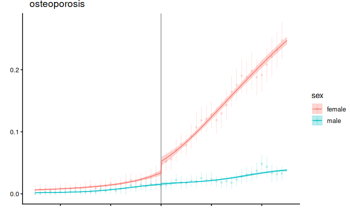

```r
#plotdf = subset(mso[["pr"]],model%in%c("pwLinear","spline","splineJump","GAMSplineGAULSS"))
plotdf = subset(mso[["pr"]],model=="splineJump")
#plotdf = mso[["bestPr"]]
plotdf[,"sex"] = "female"
mdf = cbind(msom[["bestPr"]][,c("var","x","y","yse")],sex="male")
#mdf[,"var"] = gsub("depression_score_num","depression_score",mdf[,"var"])
plotdf = rbind(plotdf[,c("var","x","y","yse","sex")],mdf)
plotdf[,"var"] = gsub("depression_score_num","depression_score",plotdf[,"var"])
#v = unique(plotdf[,"var"])
#v = subset(keep_list,group=="special_outcomes")[,"variable"]
v = c("osteoporosis","heart_attack","anemia","depression_score")
agg[,"depression_score"] = agg[,"depression_score_num"]
agg[,"depression_scorese"] = agg[,"depression_score_numse"]

names(v) = keep_list[v,"prettyname"]
g = list()
temp = agg
for (j in 1:length(v))
{
  plotSub = subset(plotdf,var==v[j])
  temp[,"y"] = agg[,v[j]]
  temp[,"yse"] = agg[,sprintf("%sse",v[j])]
  if(v[j]=="depression_score")
  {
    plotSub[,"y"] = plotSub[,"y"]*27
    plotSub[,"yse"] = plotSub[,"yse"]*27
    temp[,"y"] = temp[,"y"]*27
    temp[,"yse"] = temp[,"yse"]*27
  }
  g[[j]] = ggplot(plotSub,aes(x=x,y=y,ymin=y-yse,ymax=y+yse,colour=sex,fill=sex))+
    geom_vline(xintercept=0,colour="grey75",size=1)+
    labs(x="",y="",title=keep_list[v[j],"prettyname"])+
    geom_pointrange(data=temp,aes(x=t),alpha=.15,size=.1)+
    geom_line()+
    geom_ribbon(alpha=.3,colour=NA)+
    theme_minimal(base_size=12)+
    theme_classic(base_size=12)+
      theme(
            axis.text.x=element_blank(),
            plot.title.position = "plot", #plot or panel
            plot.title = element_text(hjust = 0.1),
            plot.margin = margin(0, 0, 0, 0),    # remove outer margin
            panel.spacing = unit(0, "lines"),   # remove spacing between panels (if faceted)
            panel.border = element_blank()      # optional: remove panel border)
    )

}
g[[1]]

library(cowplot)
gleg = cowplot::get_legend(g[[1]])

for (i in 1:length(g)) g[[i]] = g[[i]] + theme(legend.position="none")

save=T
if(save)
{
  nrow = 1
  ncol = 4
  layout = matrix(seq_len(nrow*ncol),nrow=nrow,ncol=ncol,byrow=TRUE)

ggsave(sprintf("%s/results/%s.png",outputDir,"menopause_nhanes_special_outcomes_systems_legend_bytime"),gleg,width=8,height=6)
    ggsave(sprintf("%s/results/%s.png",outputDir,"menopause_nhanes_special_outcomes_systems_bytime"),marrangeGrob(g,nrow=nrow,ncol=ncol,top=NULL,layout_matrix=layout),width=16,height=3.5)
    ggsave(sprintf("%s/results/%s.pdf",outputDir,"menopause_nhanes_special_outcomes_systems_bytime"),marrangeGrob(g,nrow=nrow,ncol=ncol,top=NULL,layout_matrix=layout),width=16,height=3.5)
}
```

other outcomes

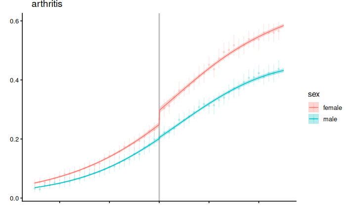

```r
#plotdf = subset(mso[["pr"]],model%in%c("pwLinear","spline","splineJump","GAMSplineGAULSS"))
plotdf = subset(mso[["pr"]],model=="splineJump")
#plotdf = mso[["bestPr"]]
plotdf[,"sex"] = "female"
plotdf = rbind(plotdf[,c("var","x","y","yse","sex")],cbind(msom[["bestPr"]][,c("var","x","y","yse")],sex="male"))
#v = unique(plotdf[,"var"])
v = subset(keep_list,group=="outcomes")[,"variable"]
#v = setdiff(unique(mso[[1]][,"var"]),subset(keep_list,group=="special_outcomes")[,"variable"])
names(v) = keep_list[v,"prettyname"]
v = v[order(systemCodex[v,"primary"],names(v))]
g = list()
temp = agg
for (j in 1:length(v))
{
  temp[,"y"] = agg[,v[j]]
  temp[,"yse"] = agg[,sprintf("%sse",v[j])]
  g[[j]] = ggplot(subset(plotdf,var==v[j]),aes(x=x,y=y,ymin=y-yse,ymax=y+yse,colour=sex,fill=sex))+
    geom_vline(xintercept=0,colour="grey75",size=1)+
    labs(x="",y="",title=keep_list[v[j],"prettyname"])+
    geom_pointrange(data=temp,aes(x=t),alpha=.15,size=.1)+
    geom_line()+
    geom_ribbon(alpha=.3,colour=NA)+
    #theme_minimal(base_size=12)+
    theme_classic(base_size=12)+
    theme(
            axis.text.x=element_blank(),
            plot.title.position = "plot", #plot or panel
            plot.title = element_text(hjust = 0.1),
            plot.margin = margin(0, 0, 0, 0),    # remove outer margin
            panel.spacing = unit(0, "lines"),   # remove spacing between panels (if faceted)
            panel.border = element_blank()      # optional: remove panel border)
    )

}
g[[1]]

library(cowplot)
gleg = cowplot::get_legend(g[[1]])

for (i in 1:length(g)) g[[i]] = g[[i]] + theme(legend.position="none")

save=T
if(save)
{
  nrow = 5
  ncol = 9
  layout = matrix(seq_len(nrow*ncol),nrow=nrow,ncol=ncol,byrow=TRUE)

ggsave(sprintf("%s/results/%s.png",outputDir,"menopause_nhanes_outcomes_systems_legend_bytime"),gleg,width=8,height=6)
    ggsave(sprintf("%s/results/%s.png",outputDir,"menopause_nhanes_outcomes_systems_bytime"),marrangeGrob(g,nrow=nrow,ncol=ncol,top=NULL,layout_matrix=layout),width=16,height=16*nrow/ncol)
    ggsave(sprintf("%s/results/%s.pdf",outputDir,"menopause_nhanes_outcomes_systems_bytime"),marrangeGrob(g,nrow=nrow,ncol=ncol,top=NULL,layout_matrix=layout),width=16,height=16*nrow/ncol)
}
```

```r
NA
NA
NA
```

compute deltas -these are differences in log-odds ratio

```r
fem=subset(mso$bestDelta,round(x,2)==3)
mal=subset(msom$bestDelta,round(x,2)==3)
if(!all.equal(fem[,"var"],mal[,"var"])) stop("females and males not aligned")
fem[,"delta"] = fem[,"y"]-mal[,"y"]
fem[,"deltase"]  = sqrt(fem[,"yse"]^2+mal[,"yse"]^2)
fem[,"pz"]  = 2*(1-pnorm(abs(fem[,"delta"])/fem[,"deltase"])) #wald test? not sure if this is right
fem[,"padj"]  = p.adjust(fem[,"pz"],method="BH")


print("pz < .1")
```

```
[1] "pz < .1"
```

```r
print(subset(fem,pz < .1)[,c("var","delta","deltase","pz","padj")])
```

|  | var | delta | deltase | pz | padj |
| --- | --- | --- | --- | --- | --- |
| 11 | osteoporosis | 0.6548585 | 0.15695967 | 3.017455e-05 | 0.0006940148 |
| 25 | chores | -0.1590410 | 0.08649209 | 6.594580e-02 | 0.5055844651 |
| 207 | copd | -0.6404722 | 0.26318831 | 1.495309e-02 | 0.2292807090 |
| 228 | liver_disease | 0.1742481 | 0.08623401 | 4.331684e-02 | 0.4981437156 |
| 242 | anemia | -0.6316218 | 0.14102926 | 7.511376e-06 | 0.0003455233 |
| 270 | sleep_disorder | 0.2160371 | 0.12713748 | 8.927393e-02 | 0.5866572224 |
| 319 | smoke_now | 0.1360012 | 0.07277120 | 6.163837e-02 | 0.5055844651 |

```r
print("BH adjusted p < .05:")
```

```
[1] "BH adjusted p < .05:"
```

```r
print(subset(fem,padj < .05)[,c("var","delta","deltase","pz","padj")])
```

|  | var | delta | deltase | pz | padj |
| --- | --- | --- | --- | --- | --- |
| 11 | osteoporosis | 0.6548585 | 0.1569597 | 3.017455e-05 | 0.0006940148 |
| 242 | anemia | -0.6316218 | 0.1410293 | 7.511376e-06 | 0.0003455233 |

depression score properties - known menopause timing note these are ordinal-coded (if you have moderate depression then you also have worse depression)

```r
#aggregated data #these are outcome OR WORSE
load=T
save=T
file = sprintf("%s/results/nhanes_menopause_timing.csv",outputDir)

if(file.exists(file)&load)
{
  aggDep = read.csv(file)
} else
{
  stop("data not found")
}

tab = matrix(NA,nrow=2,ncol=2)
dimnames(tab)=list(year1=c("no","yes"),past_year1=c("no","yes"))
tab[1,1] = subset(aggDep,time_to_menopause<1.1)[,"no_moderate_depression"]
tab[1,2] = subset(aggDep,time_to_menopause<1.1)[,"moderate_depression"]    #includes or worse
tab[2,1] = sum(subset(aggDep,time_to_menopause>1.1)[,"no_moderate_depression"],na.rm=T)
tab[2,2] = sum(subset(aggDep,time_to_menopause>1.1)[,"moderate_depression"],na.rm=T) #includes or worse


# Run Fisher's exact test
print(sprintf("moderate depression rates 1 year after (mean: %.0f/%.0f= %.2f) menopause vs later (mean: %.0f/%.0f= %.2f):",
              tab[1,2],sum(tab[1,]),tab[1,2]/sum(tab[1,]),tab[2,2],sum(tab[2,]),tab[2,2]/sum(tab[2,])))
```

```
[1] "moderate depression rates 1 year after (mean: 60/323= 0.19) menopause vs later (mean: 794/7306= 0.11):"
```

```r
print(tab)
```

```
     past_year1
year1   no yes
  no   263  60
  yes 6512 794
```

```r
print(fisher.test(tab))
```

```
    Fisher's Exact Test for Count Data

data:  tab
p-value = 6.233e-05
alternative hypothesis: true odds ratio is not equal to 1
95 percent confidence interval:
 0.3981904 0.7269425
sample estimates:
odds ratio
 0.5344784
```

#supplemental figures

#Fig S1 use yoglen_validation_step_function.Rmd

#Fig S2 use yoglen_simulation_study.Rmd

#Fig S3 NHANES vs SWAN load in aggregated data…

```r
save=T
load=T

aggopts =  "stats"
aggopts = sprintf("%s_ac",aggopts)
aggf   = read.csv(sprintf("%s/results/nhanes_menopause_female_mean_%s.csv",outputDir,aggopts))
aggfsd   = read.csv(sprintf("%s/results/nhanes_menopause_female_sd_%s.csv",outputDir,aggopts))

aggm   = read.csv(sprintf("%s/results/nhanes_menopause_male_mean_%s.csv",outputDir,aggopts))
aggmsd   = read.csv(sprintf("%s/results/nhanes_menopause_male_sd_%s.csv",outputDir,aggopts))

swanFile = sprintf("%s/data/swan_mean_fsh_and_e2.csv",outputDir)
if(file.exists(swanFile)&load)
{
  swanAgg = read.csv(swanFile)
} else
{
  swanDir = "/home/glen/postdoc/menopause/data"
  swanData = read.csv(sprintf("%s/swan_preproc_fsh_and_e2.csv",swanDir),row.names=1)
  swanData[,"menopause"] = 1*(swanData[,"t"] >= 0)
  #log scale
  swanData[,"fsh"] = log(swanData[,"fsh"])
  swanData[,"e2"] = log(swanData[,"e2"])

  keepMe = c("t","age","fsh","e2")
  swanData[,"tcut"] = cut(swanData[,"t"],seq(-10.5,10,by=1),include.lowest=T)
  swanAgg = aggregate(swanData[,keepMe],by=swanData[,"tcut",drop=F],mean,na.rm=T)
  swanAgg[,sprintf("%sse",keepMe)] = aggregate(swanData[,keepMe],by=swanData[,"tcut",drop=F],SEM,na.rm=T)[,keepMe]
  swanAgg[,sprintf("%ssd",keepMe)] = aggregate(swanData[,keepMe],by=swanData[,"tcut",drop=F],sd,na.rm=T)[,keepMe]

  if(save) write.csv(swanAgg,swanFile,row.names=F)
}
```

barebones comparison - just compare binned data

```r
temp = aggf
temp[,"type"] = "NHANES"
rownames(temp) = temp[,"t"]
rownames(swanAgg)  = round(swanAgg[,"t"])
#rownames(swanAgg) = swanAgg[,"tcut"]
for (v in  c("e2","e2se","fsh","fshse")) temp[rownames(swanAgg),sprintf("swan_%s",v)] = swanAgg[,v]

print('e2 cor:')
```

```
[1] "e2 cor:"
```

```r
print(cor.test(temp[,"swan_e2"],temp[,"e2"],use='complete'))
```

```
    Pearson's product-moment correlation

data:  temp[, "swan_e2"] and temp[, "e2"]
t = 21.57, df = 18, p-value = 2.602e-14
alternative hypothesis: true correlation is not equal to 0
95 percent confidence interval:
 0.9520698 0.9926925
sample estimates:
      cor
0.9812004
```

```r
print('fsh cor:')
```

```
[1] "fsh cor:"
```

```r
print(cor.test(temp[,"swan_fsh"],temp[,"fsh"],use='complete'))
```

```
    Pearson's product-moment correlation

data:  temp[, "swan_fsh"] and temp[, "fsh"]
t = 38.8, df = 18, p-value < 2.2e-16
alternative hypothesis: true correlation is not equal to 0
95 percent confidence interval:
 0.9847398 0.9977060
sample estimates:
      cor
0.9940748
```

```r
temp = subset(temp,t >= -10 & t <= 10)

g = list()
g[[1]] = ggplot(temp,aes(x=swan_e2,xmin=swan_e2-swan_e2se,xmax=swan_e2+swan_e2se,y=e2,ymin=e2-e2se,ymax=e2+e2se,colour=t))+
    geom_smooth(method="lm",colour="grey50")+
    scico::scale_color_scico(palette='roma')+
    geom_point()+
    geom_errorbar(width=0)+
    geom_errorbarh(height=0)+
    #annotate("text",x=4.25,y=-1.75,label=sprintf("r=%.2f",cor(temp[,"swan_e2"],temp[,"e2"],use='complete')))+
    geom_text_repel(data=data.frame(x=3.375,y=-1.1,label=sprintf("r=%.2f",cor(temp[,"swan_e2"],temp[,"e2"],use='complete'))),aes(x=x,y=y,label=label),inherit.aes=F,show.legend=F,size=11,nudge_x=.25,nudge_y=-.2,seed=0)+
    labs(x="SWAN (log-scale)",y="NHANES (z-score)",title="a) e2",colour="Time since menopause (years)")+#,title=sprintf("y%02d",j))+
    theme_minimal(base_size=24)+
    theme(
        legend.title=element_text(size=14),
        legend.position=c(.25,.8)
        )

g[[2]] = ggplot(temp,aes(x=swan_fsh,xmin=swan_fsh-swan_fshse,xmax=swan_fsh+swan_fshse,y=fsh,ymin=fsh-fshse,ymax=fsh+fshse,colour=t))+
    geom_smooth(method="lm",colour="grey50")+
    scico::scale_color_scico(palette='roma')+
    geom_point()+
    geom_errorbar(width=0)+
    geom_errorbarh(height=0)+
    #annotate("text",x=4.25,y=-.25,label=sprintf("r=%.2f",cor(temp[,"swan_fsh"],temp[,"fsh"],use='complete')))+
    geom_text_repel(data=data.frame(x=4.1,y=1.5,label=sprintf("r=%.2f",cor(temp[,"swan_fsh"],temp[,"fsh"],use='complete'))),aes(x=x,y=y,label=label),inherit.aes=F,show.legend=F,size=11,nudge_x=.25,nudge_y=-.2,seed=0)+
    labs(x="SWAN (log-scale)",y="NHANES (z-score)",title="b) fsh")+#,title=sprintf("y%02d",j))+
    theme_minimal(base_size=24)+
    theme(
        legend.position="none",
        legend.title=element_blank()
        )

save=T
if(save)
{
  nrow = 1
  ncol = 2
  layout = matrix(c(1:length(g),rep(NA,nrow*ncol)),nrow=nrow,ncol=ncol,byrow = T)
  ggsave(sprintf("%s/results/figs3.pdf",outputDir),marrangeGrob(g,nrow=nrow,ncol=ncol,layout_matrix = layout,top=NULL,widths=c(.5,.5)),width=16,height=7)
  ggsave(sprintf("%s/results/figs3.png",outputDir),marrangeGrob(g,nrow=nrow,ncol=ncol,layout_matrix = layout,top=NULL,widths=c(.5,.5)),width=16,height=7)
  #ggsave(sprintf("%s/results/nhanes_menopause_model_selection_e2_and_fsh_legend.pdf",outputDir),gleg,width=8,height=8)
}
```

#Fig S4 Males vs Age load cross-validated model

```r
source(sprintf("%s/menopause_script.R",outputDir),verbose=0)
load=T
save=T

filem=sprintf("%s/results/nhanes_menopause_model_selection_males_%s.rds",outputDir,"ac") #available case

if(file.exists(filem) & load)
{
  msm=readRDS(filem)
} else
{
  stop("use nhanes_menopause_model_selection.Rmd to be up to date")
}
```

fig s4

```r
dataFile = sprintf("%s/data/nhanes_male_data.csv",outputDir)
useSim=F
if(file.exists(dataFile)) #real data
{
    print("real data found")
  Xm = read.csv(dataFile,row.names=1) #real data
} else #sim data
{
  print("real data not found, using simulated...")
  useSim =  T
  Xm = read.csv(sprintf("%s/data/simulated_nhanes_male.csv",outputDir),row.names=1)

  Xm[,"RIDAGEYR"] = Xm[,"age"] #I named it differently in the simulated data
}
```

```
[1] "real data not found, using simulated..."
```

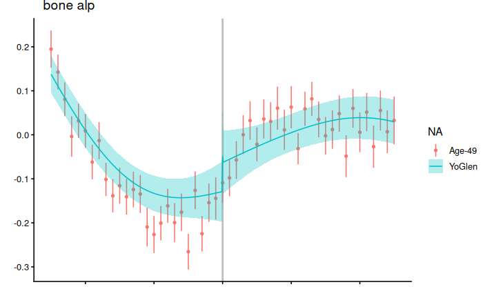

```r
temp = Xm
temp[,"x"] = Xm[,"RIDAGEYR"]-49
temp[,"group"] = "Age-49"
temp = subset(temp,x >= -25 & x <= 25)

#plotdf = subset(ms[["pr"]],model%in%c("pwLinear","spline","splineJump","GAMSplineGAULSS"))
#plotdf = subset(ms[["pr"]],model%in%c("pwGAULSS","pwSpline","highKSplineJump","highKSpline"))
plotdf = msm[["bestPr"]]
plotdf[,"group"] = "YoGlen"

v = unique(plotdf[,"var"])
names(v) = keep_list[v,"prettyname"]
v = v[order(systemCodex[v,"primary"],names(v))]


g = list()
for (j in 1:length(v))
{
  temp[,"y"] = temp[,v[j]]

  g[[j]] = ggplot(temp,aes(x=x,y=y,colour=group,fill=group))+
    geom_vline(xintercept=0,size=1,colour="grey75")+
    stat_summary(size=.1)+
    #geom_smooth(method="gam",formula=y~s(x))+
    labs(x="",y="",title=keep_list[v[j],"prettyname"],colour=NA,fill=NA)+
    geom_line(data=subset(plotdf,var==v[j]))+
    geom_ribbon(data=subset(plotdf,var==v[j]),aes(ymin=y-yse,ymax=y+yse),alpha=.3,colour=NA)+
    #theme_minimal(base_size=12)+
    theme_classic(base_size=12)+
      theme(
            axis.text.x=element_blank(),
            plot.title.position = "plot", #plot or panel
            plot.title = element_text(hjust = 0.1),
            plot.margin = margin(0, 0, 0, 0),    # remove outer margin
            panel.spacing = unit(0, "lines"),   # remove spacing between panels (if faceted)
            panel.border = element_blank()      # optional: remove panel border)
    )

}
g[[1]]

library(cowplot)
gleg = cowplot::get_legend(g[[1]])

for (i in 1:length(g)) g[[i]] = g[[i]] + theme(legend.position="none")

save=T
if(save)
{
  nrow = 10
  ncol = 9
  layout = matrix(seq_len(nrow*ncol),nrow=nrow,ncol=ncol,byrow=TRUE)

ggsave(sprintf("%s/results/%s.png",outputDir,"fig3s_males_legend"),gleg,width=8,height=6)
    ggsave(sprintf("%s/results/%s.png",outputDir,"fig3s_males"),marrangeGrob(g,nrow=nrow,ncol=ncol,top=NULL,layout_matrix=layout),width=16,height=16*nrow/ncol)
    ggsave(sprintf("%s/results/%s.pdf",outputDir,"fig3s_males"),marrangeGrob(g,nrow=nrow,ncol=ncol,top=NULL,layout_matrix=layout),width=16,height=16*nrow/ncol)
}
```

```r
NA
```

#Fig S5 - HRT usage

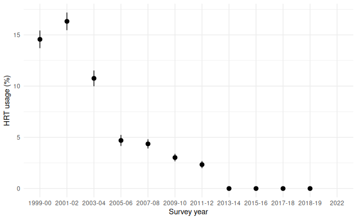

```r
file = sprintf("%s/data/survey_year_hrt.csv",outputDir)
load=T
save=T
if(file.exists(file) & load)
{
  aggHRTSum = read.csv(file)
} else
{
  #won't work, no survey year in simulated data :(
    #needs real data
  Xf[,"survey_year"] = dplyr::case_when(
                      Xf[,"surveyf"] == 1        ~ "1999-00",
                      Xf[,"surveyf"] == 2        ~ "2001-02",
                      Xf[,"surveyf"] == 3        ~ "2003-04",
                      Xf[,"surveyf"] == 4        ~ "2005-06",
                      Xf[,"surveyf"] == 5        ~ "2007-08",
                      Xf[,"surveyf"] == 6        ~ "2009-10",
                      Xf[,"surveyf"] == 7        ~ "2011-12",
                      Xf[,"surveyf"] == 8        ~ "2013-14",
                      Xf[,"surveyf"] == 9        ~ "2015-16",
                      Xf[,"surveyf"] == 10       ~ "2017-18",
                      Xf[,"surveyf"] == 12       ~ "2022",
                      Xf[,"surveyf"] == 66       ~ "2018-19",
                      is.na(Xf[,"surveyf"])      ~ NA_character_)

aggHRTSum = aggregate(Xf[,"bin_hrt_now",drop=F],by=Xf[,"survey_year",drop=F],mean,na.rm=T)
aggHRTSum[,"se"] = aggregate(Xf[,"bin_hrt_now",drop=F],by=Xf[,"survey_year",drop=F],SEM,na.rm=T)[,"bin_hrt_now"]
  if(save) write.csv(aggHRTSum,file,row.names=F)
}


g = ggplot(aggHRTSum,aes(x=survey_year,y=100*bin_hrt_now,ymin=100*(bin_hrt_now-se),ymax=100*(bin_hrt_now+se)))+
  geom_pointrange()+
  labs(x="Survey year",y="HRT usage (%)")+
  theme_minimal()
g
save=TRUE
if (save)
{
  ggsave(sprintf("%s/results/figs5_hrt_usage.pdf",outputDir),g,width=8,height=5)
  ggsave(sprintf("%s/results/figs5_hrt_usage.png",outputDir),g,width=8,height=5)
}
```